[GitHub](https://github.com/agate-model/workshops)[](https://github.com/agate-model/workshops/blob/main/2026-05/examples/01_quick_start.jl)

# Exercise 01: Quick start

This exercise constructs an Agate biogeochemistry model, wraps it in an OceanBioME `Biogeochemistry`, places it in an Oceananigans `BoxModel`, sets initial tracer values, and runs a simulation.

## Loading dependencies

```julia
using Agate
using Agate.Introspection: tracer_names
using Agate.Library.Light
using OceanBioME
using OceanBioME: Biogeochemistry
using Oceananigans
using Oceananigans.Units
using CairoMakie
workshop_script = let dir = @__DIR__
    while !isfile(joinpath(dir, "src", "AgateWorkshop.jl"))
        parent = dirname(dir)
        parent == dir && error("Could not find src/AgateWorkshop.jl")
        dir = parent
    end
    joinpath(dir, "src", "AgateWorkshop.jl")
end
include(workshop_script)


mkpath(joinpath("outputs"))
mkpath(joinpath("figures"))
```

## Agate.jl Quick start, step by step

First construct the default two-phytoplankton, two-zooplankton NiPiZD model.

```julia
bgc = Agate.Models.NiPiZD.construct()
println(tracer_names(bgc))
```

```
[:N, :D, :Z1, :Z2, :P1, :P2]
```

The Quick start uses a seasonal photosynthetically active radiation field for a zero-dimensional box.

```julia
light_attenuation = FunctionFieldPAR(; grid=BoxModelGrid())
```

OceanBioME adapts the Agate biogeochemistry to an Oceananigans model.

```julia
bgc_model = Biogeochemistry(bgc; light_attenuation)
full_model = BoxModel(; biogeochemistry=bgc_model)
```

Set the initial tracer concentrations. The helper distributes the total plankton biomass evenly across the plankton tracers in `bgc`.

```julia
set!(full_model; default_initial_conditions(bgc)...)
```

Run the model and save daily tracer output.

```julia
quickstart_filename = joinpath("outputs", "01_quick_start_manual.jld2")
simulation = Simulation(full_model; Δt=240minutes, stop_time=1095days)

simulation.output_writers[:fields] = JLD2Writer(
    full_model,
    full_model.fields;
    filename=quickstart_filename,
    schedule=TimeInterval(1day),
    overwrite_existing=true,
)

run!(simulation)
```

```
[ Info: Initializing simulation...
[ Info:     ... simulation initialization complete (2.015 seconds)
[ Info: Executing initial time step...
[ Info:     ... initial time step complete (557.639 ms).
[ Info: Simulation is stopping after running for 6.684 seconds.
[ Info: Simulation time 1095 days equals or exceeds stop time 1095 days.
```

## Reading and plotting the output

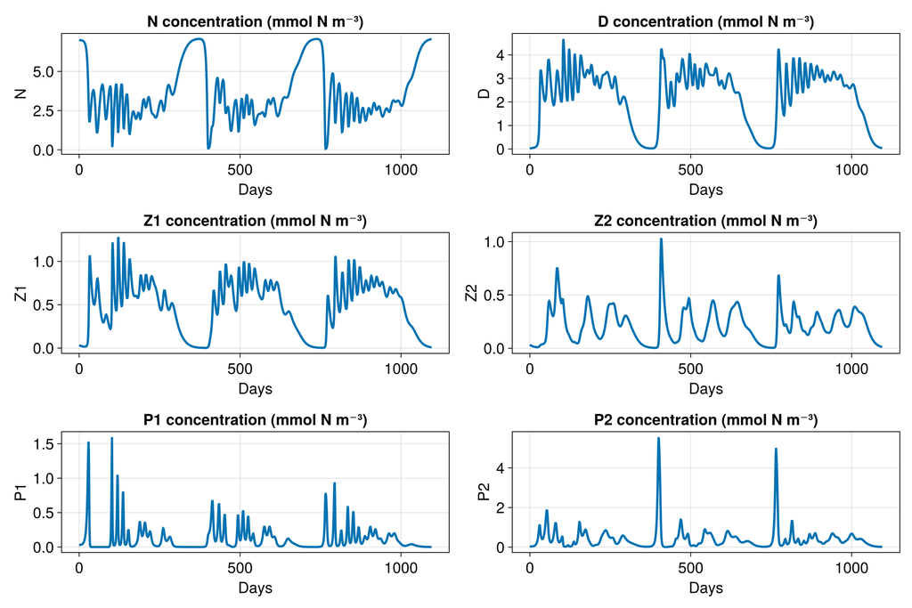

```julia
tracer_syms = tracer_names(bgc)
timeseries = read_box_tracer_timeseries(quickstart_filename, tracer_syms)

fig_manual = Figure(; size=(1200, 800), fontsize=20)

for (idx, sym) in enumerate(tracer_syms)
    row = floor(Int, (idx - 1) / 2) + 1
    col = Int((idx - 1) % 2) + 1
    ax = Axis(
        fig_manual[row, col];
        ylabel=string(sym),
        xlabel="Days",
        title="$(sym) concentration (mmol N m⁻³)",
    )
    lines!(ax, timeseries.times, timeseries.data[Symbol(sym)]; linewidth=3)
end

save(joinpath("figures", "01_quick_start_manual.png"), fig_manual)
display(fig_manual)
fig_manual
```

## A general workshop box-model wrapper

The same setup will appear repeatedly in later exercises. The workshop helper script therefore defines:

- `default_initial_conditions(bgc; total_plankton_biomass, nutrient, detritus)`
- `build_box_model(bgc; light_attenuation, initial_conditions)`
- `run_box_model(bgc; filename, initial_conditions, Δt, stop_time, output_interval)`
- `read_box_tracer_timeseries(filename, tracer_syms)`

The wrapper takes `bgc` as an argument, so it can be reused with more complex Agate models without manually spelling out every plankton tracer.

```julia
wrapped = run_box_model(
    bgc;
    filename=joinpath("outputs", "01_quick_start_wrapped.jld2"),
    Δt=240minutes,
    stop_time=1095days,
    output_interval=1day,
)

wrapped_timeseries = read_box_tracer_timeseries(wrapped.filename, wrapped.tracer_syms)
```

```
[ Info: Initializing simulation...
[ Info:     ... simulation initialization complete (2.189 ms)
[ Info: Executing initial time step...
[ Info:     ... initial time step complete (156.344 μs).
[ Info: Simulation is stopping after running for 3.825 seconds.
[ Info: Simulation time 1095 days equals or exceeds stop time 1095 days.
```

The wrapper is also useful when we change model complexity. Here we construct a larger NiPiZD community and use the same `run_box_model` function.

```julia
larger_bgc = Agate.Models.NiPiZD.construct(
    phyto_size_structure=(n=3, min_esd=1.0, max_esd=10.0, splitting=:log_splitting),
    zoo_size_structure=[10.0, 32.0, 100.0],
)

larger = run_box_model(
    larger_bgc;
    filename=joinpath("outputs", "01_quick_start_larger_community.jld2"),
    initial_conditions=default_initial_conditions(larger_bgc; total_plankton_biomass=0.06),
    Δt=240minutes,
    stop_time=365days,
    output_interval=1day,
)

println(larger.tracer_syms)
```

```
[ Info: Initializing simulation...
[ Info:     ... simulation initialization complete (989.409 ms)
[ Info: Executing initial time step...
[ Info:     ... initial time step complete (840.370 ms).
[ Info: Simulation is stopping after running for 2.947 seconds.
[ Info: Simulation time 365 days equals or exceeds stop time 365 days.
[:N, :D, :Z1, :Z2, :Z3, :P1, :P2, :P3]
```